# Maine’s Climate is Rising at an Alarming Rate: Orienting Indigenous Narratives and Low-Income Individuals in Vital Climate Conversations

Owen Hoffsten

8/31/2020

## What’s at Stake?

Maine is a geographically diverse state with coastal, mountainous, and flat areas throughout it. The state is characterized by a mountainous and rural inland, and large coastal area. Its economy depends on agriculture, commercial fishing, and tourism. Its climate is a humid continental one, with humid and warm summers and cold winters with abundant snowfall.

[figure not shown]

Map of Maine

While the United States experiences a progressively concerning yearly increase in temperature, Maine experiences an even greater increase. More specifically, Maine and the Northeast are warming faster than any region in the U.S. — that is, while the rest of the country is projected to reach 3.6 degrees (F) in warming, the Northeast will reach 5.4 degrees (F) (Fernandez et al. 3). In Celsius, this statistic is 2 degrees and 3 degrees, respectively. The implications of such a temperature rise on the Maine coastal and agricultural landscape will be profound.

What’s at stake in these rising temperatures? From social to economic losses, Maine will suffer. From rising sea levels and an increased frequency of extreme weather events, millions of dollars in property damage will occur. An amended growing season will also make agriculture a far more difficult industry to maintain than in the past. Additionally, altered environmental conditions will cause tourism to suffer. And above all of this, those who are low-income, Black, Indigenous, and people of color (BIPOC) will be disproportionately impacted by such climate events. A variety of activists in Maine have already been engaging these topics. For instance, Sirohi Kumar, a 16-year old from Bar Harbor, is a strong proponent of the empowerment of Maine’s indigenous people. Particularly, she believes that giving Indigenous people sovereignty over their land “will not only help end racism but will also promote sustainable farming and other environmentally responsible practices that are often practiced in indigenous communities” (Thill).

The implications of such damage on climate activism efforts cannot be understated. Understanding what will happen to the Maine environment in the future is essential to the framing of Maine climate activist narratives.

Despite a massive and holistic body of evidence, some will still deny the actual temperature increase, assuming that such heat rise is cyclical and should be assumed to be normal. To investigate this, I analyzed temperature trends in Maine.

## How Do We Prove the Increase is Real?

[figure not shown]

Map of Portland, ME

To test this warming trend, temperature data from Portland Maine Jetport was downloaded from National Oceanic and Atmospheric Administration (NOAA) and evaluated using R. Multiple linear models were created and trendlines were applied to each model. A trend between time and temperature was evaluated through the null hypothesis, which predicts that there is no trend between the two variables, time and temperature. A rejection of the null hypothesis means that there is a trend between time and temperature. The p-value will be calculated from this relationship, from which we can assess the null hypothesis. A p-value of less than 0.05 leads to a rejection of the null hypothesis and thus the confirmation of a trend between time and temperature.

## The Increase is Real — and Alarming

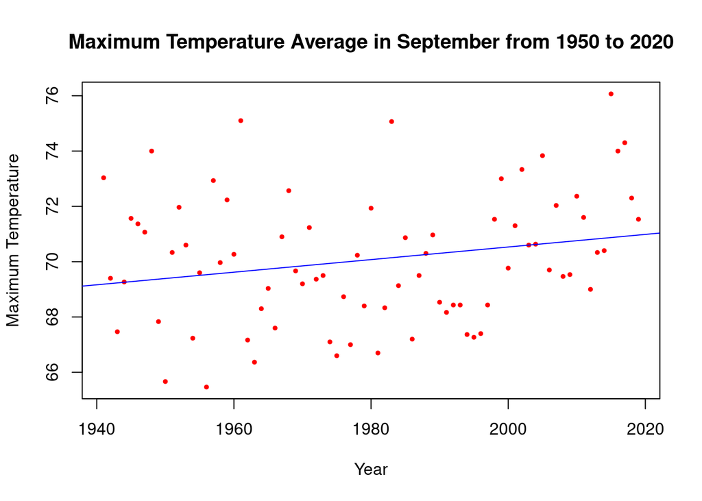

The linear model for the data has a p-value of <0.05 The slope is 0.03. Since the p-value is less than 0.05, we can reject the null hypothesis and acknowledge a trend between time and temperature. The R-squared value is 0.04.

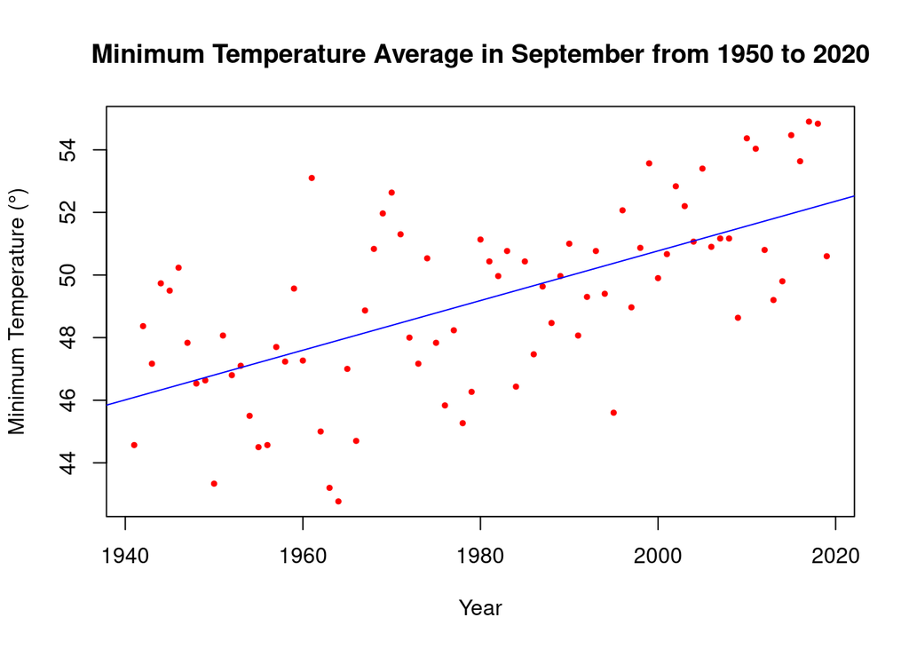

As shown above, both minimum and maximum temperature are increasing, but the average daily minimum temperature is increasing even faster than the maximum.

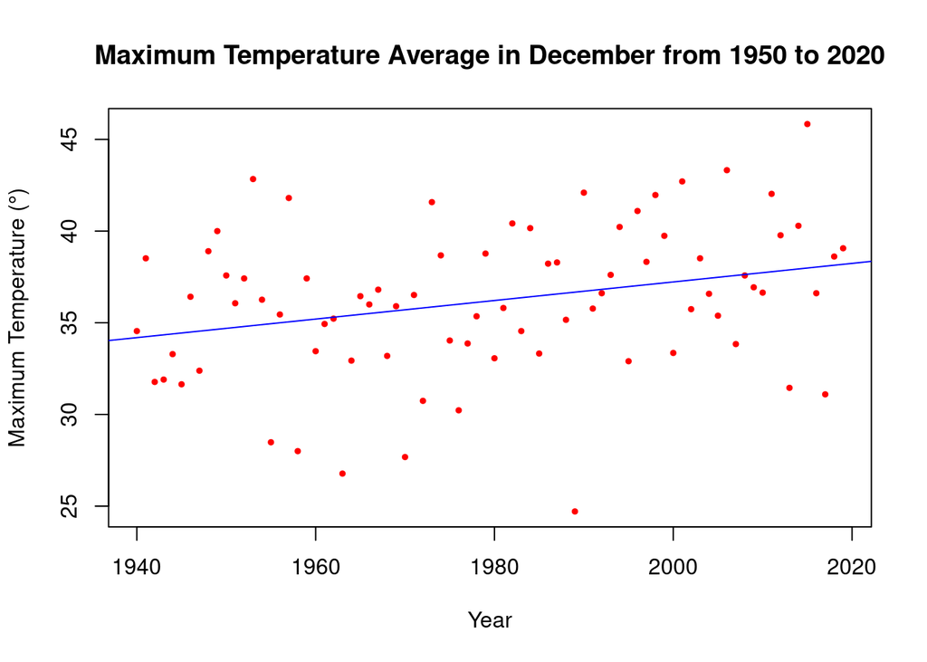

This graph has a slope of 0.05 with a p-value of <0.01. Since the p-value is less than 0.05, we can reject the null hypothesis, and acknowledge a positive trend between time and temperature. The R-squared value is 0.07.

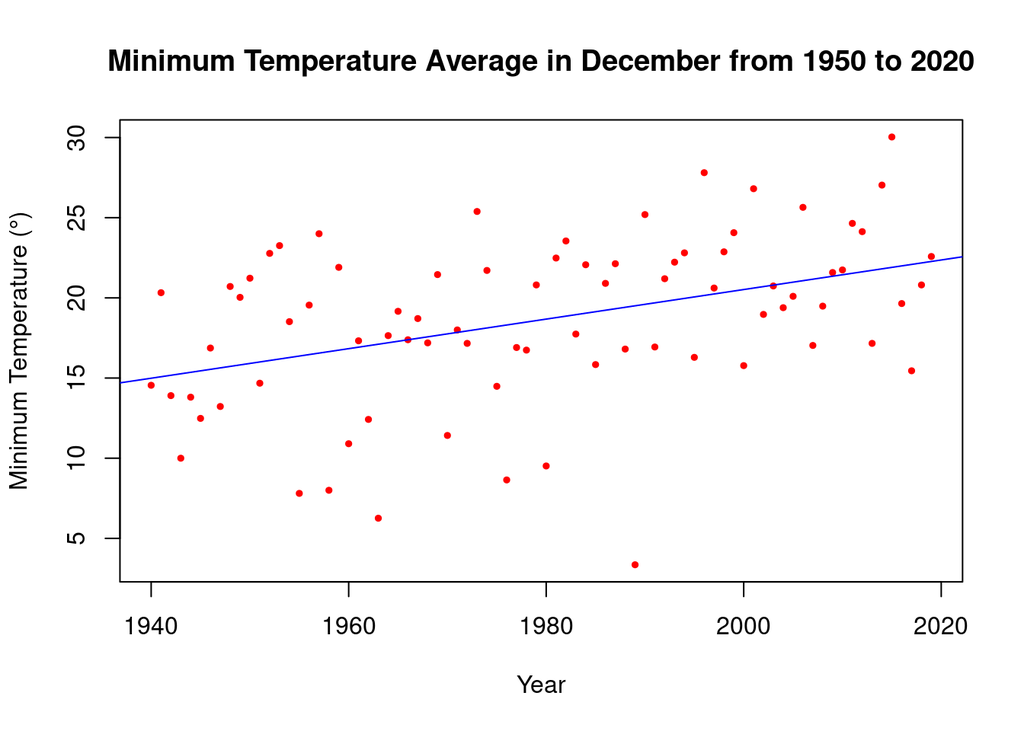

In this final graph, the slope is 0.092.The R-squared value is 0.16. Having a p-value of <0.001, as you might have guessed, means that we can reject the null hypothesis and acknowledge a trend between time and temperature.

From this data, we see that Maine’s temperatures are increasing just as predicted by other sources.

## Some Limitations of the Data

Limitations of this data include a lack of information about other weather and climate trends. Future analysis of factors such as sea level rise and precipitation would help add to the conversation surrounding regional climate change in Portland, Maine.

Also, due to Portland’s coastal climate, temperatures vary between locations right on the coast and those that are more inland. Portland Jetport, the site at which the data was collected, is an inland location, meaning that its temperatures may vary from coastal temperatures.

## What Does This Mean for the State’s Future?

As mentioned before, the implications of such a temperature increase, especially one projected to be 1 degree (C) above the rest of the United States, cannot be understated.

The EPA explains that such temperature increases will result in numerous harmful effects in the state of Maine. With the increasing temperature comes sea level rise, resulting in shoreline erosion, storm surges, and increasing damage to infrastructure. Damage to coastal homes, highways, rail lines, and other infrastructure will ensue by way of storms and floods. With the increase of sea surface temperatures by almost 2 degrees (F) since 1970, the rate at which the sea level is rising has accelerated, and it is projected to rise between 1 and 4 feet more by 2100 (United States Environmental Protection Agency 1). Some coastal Maine cities and towns may lose up to 30% of their land area. Sea level rise will also cause increased tidal and coastal flooding that will influence damage to infrastructure and overwhelm storm drains (NOAA Maine - State Summaries 2019). All of the aforementioned disasters and alterations to the ecosystem increase, as mentioned by the EPA, will disproportionately impact low-income people and people of color, as well as children, the elderly, and at-risk populations (United States Environmental Protection Agency 2).

Already, tidal flooding has cost Maine real estate $70 million dollars, with damage concentrated in Kennebunkport, Saco, Scarborough, Biddeford, and Bath. Additionally, the risk of coastal storms threatens numerous areas in Maine, even those deemed ‘low-risk’ — in fact, over 20% of flood insurance claims come from outside of high-risk areas. Currently, various towns in Maine are engaging in climate planning efforts to become resilient to such increased flooding (Fernandez et. al 17) .

Rising CO2 in the atmosphere facilitates more potent pollen seasons and fossil fuel burning, a main contributor to CO2 emissions, carries with it air pollutants such as ozone, lead, mercury, acid, rain, and soot. Air pollution disproportionately affects and exacerbates the conditions of those with asthma, kidney disease, diabetes, and bone weakening. Additionally, those most at risk of the harmful health effects of air pollution include older adults, people who spend large portions of their time outdoors, low-income people, and people who live and/or work near highways. Oftentimes, the latter two are intertwined (Fernandez et al. 20). Damages from lost labor hours and deaths that are a product of worse air quality and increases in extreme temperature contribute to billions of dollars in damage each year (Fernandez et al. 20)

# How Do These Increases Impact Agriculture and Aquaculture?

The six warmest years in Maine’s history have been recorded since 1998 (Fernandez et al. 7). Such conditions will result and have already resulted in a growing season that is two weeks longer than it was in 1950, which may improve agricultural conditions temporarily (Fernandez et al. 4). However, although there is uncertainty over whether or not drought will become more frequent in the future, as the climate continues to warm, droughts and limited moisture periods will likely worsen. The impacts on farmers and forest ecosystems will be acute — in fact, between 2000 and 2016, droughts cost the country about $74 billion. Droughts oftentimes lead to insect/disease outbreaks impacting trees, resulting in depopulation of species and increased fire risk (Fernandez et al. 7). With temperature increase comes comes precipitation in the place of snow. Maine continues to experience more ‘winter weather whiplash’ as well, a term that denotes rapid and spontaneous shifts between thawing and freezing conditions, heat waves in winter, and cold waves and snow in late spring and early fall (Fernandez et al. 9).

Agriculture is not the only industry that will suffer with rising temperatures. Recent warming is due to flows of warm and salty water to the Northeast channel. This process will ultimately result in less nutrients reaching the surface of the ocean, thus rendering the Gulf as less productive. Ocean acidification along with rising ocean temperatures will cause industries that rely on marine fishing to suffer — particularly that of lobster, which is so central to Maine’s economy (Fernandez et al. 12).

## Maine’s Indigenous People are Subject to Perpetual Disenfranchisement by Climate Change and Something Must be Done

Making up 0.62% of Maine’s entire population, Indigenous people are oftentimes excluded from conversations around climate change despite their deep connections to the issue. Compared to the rest of the state, Indigenous People have per capita incomes of 12,700 USD while the rest of the state averages 19,272 USD; they tend to die at younger ages than other Maine residents (60 years vs. 74 years), experience higher rates of tobacco addiciton, alcohol use, and obesity; and may die at higher rates from cancer (Jacobson 39). Barriers to their own health include lack of access to transportation, low incomes, racism, sparse healthcare infrastructure and policy, and threats from environmental hazards like dioxin, mercury, lead, arsenic, and cadmium. Altogether, due to Maine’s Indigenous People’s vulnerable position within Maine, they will likely continue to be disproportionately affected by climate change and environmental hazards in the coming years.

The Wabanaki people of Maine have existed for over 12,000 years, and over the course of this time, they have shown resiliience to numerous changes in the climate, surviving environmental degradation, financial destitution, and oppressive colonial domination. The Maine Indigenous people’s immense resilience to violence against them is exemplary of their abilities to mitigate climate change and environmental harm in the future. Some potential environmental and economic solutions Indigenous people may be exploring are developing wind and solar power on tribal land and implementing carbon sequestration through Maine tribal forest land (Jacobson et al. 39).

## Conclusion

As can be seen from the results of rising temperatures in Maine, an immense amount is at stake. A report by the Department of Sociology and Anthropology at St. Francis Xavier University states that workers are typically discouraged from climate activism due to fear of job loss, a fear underlined by the economically dependent nature of the region (Bantjes 6). In the future efforts of climate activists, in order to engage all stakeholders, climate narratives must focus on the social, economic, and political losses that will ensue if we do nothing to mitigate the rise of temperature across the state. Additionally, the needs of Indigenous people must be incorporated like they never have been before. Thus far in the conversation around climate justice, Indigenous people’s voices have been absent, and with this absence, their needs and concerns have become stifled. Contextualized within their disenfranchised economic condition and with much of their land dispossessed, Indigenous people’s needs must be met, needs that, as Kumar mentions, include granting land sovereignty. Indigenous knowledge should be viewed as a valuable cultural resource in orienting climate activist narratives.

As Maine continues to engineer and implement numerous climate initiatives and plans, policymakers and organizers must make sure to include disenfranchised and marginalized groups as stakeholders in the climate conversation, not only for the sake of low-income and BIPOC themselves, but also for the sake of the future of the state of Maine. In other words, as indigenous climate activist Sheri Mitchell says, “critical issues like the contamination of our waterways get couched as indigenous issues, when in fact these are issues of human survival” (NowThis).

Engaging and empowering those who will be most affected by the brutal effects of climate change and those who know the land are essential steps Maine should be taking to mitigate the effects of rapidly rising temperatures.

## Bibliography

“NOAA National Centers for Environmental Information State Climate Summaries.” Maine - State Summaries 2019, statesummaries.ncics.org/chapter/me/.

Fernandez, Ivan, et al. “Maine’s Climate Future: 2020 Update.” The University of Maine Climate Change Institute, 2020, climatechange.umaine.edu/wp-content/uploads/sites/439/2020/02/Maines-Climate-Future-2020-Update-3.pdf.

“What Climate Change Means for Maine.” United States Environmental Protection Agency, 2016, 19january2017snapshot.epa.gov/sites/production/files/2016-09/documents/climate-change-me.pdf.

Jacobson, George L., et al. “Maine’s Climate Future: an Initial Assessment.” DigitalCommons at UMaine, digitalcommons.library.umaine.edu/ers_facpub/177/.

Bantjes, Rod. “Hegemony and the Power of Constitution: Labour and Environmental Coalition-Building in Maine and Nova Scotia.” Studies in Political Economy, no. 54, 1997.

Thill, David. “Meet the Young People Pushing Maine Forward on Climate Change.” Energy News Network, 7 Aug. 2020, energynews.us/2020/08/05/northeast/meet-the-young-people-pushing-maine-forward-on-climate-change/.

NowThis. “Indigenous Activist Sherri Mitchell Fights For Environmental Justice.” NowThis News, 2020, nowthisnews.com/news/indigenous-activist-sherri-mitchell-fights-for-environmental-justice.